# Introduction to Unix and the command line

July 19, 2014

## The Command Line

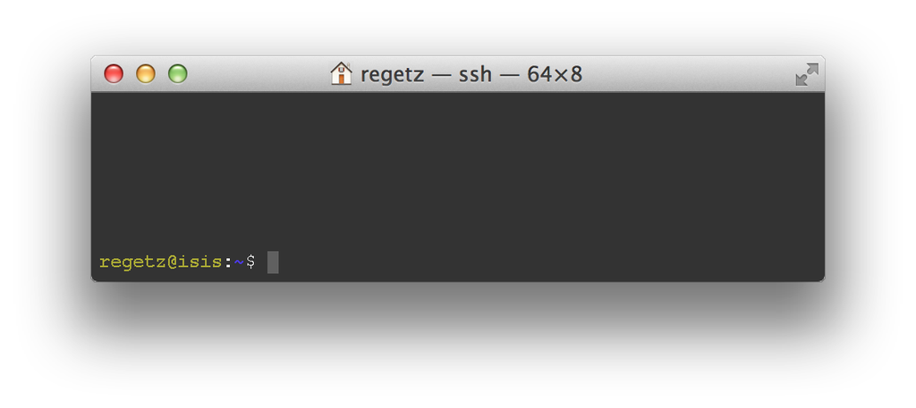

## The operating system

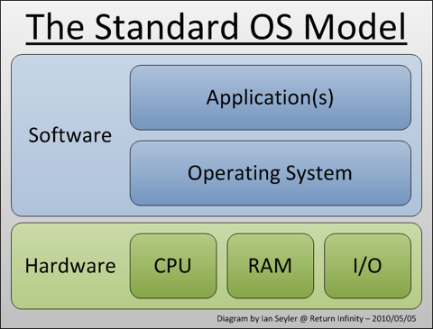

## All about the X

[figure not shown]

**UNIX**

Originally developed at AT&T Bell Labs circa 1970. Has experienced a [contentious, fractured evolution](https://upload.wikimedia.org/wikipedia/commons/7/77/Unix_history-simple.svg)

**POSIX**

think of this as a set of specifications of what an OS needs to qualify as "a Unix"

## All about the X

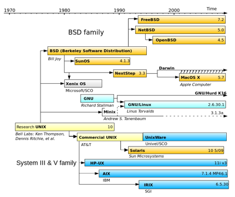

- **OS X**

  [is a Unix](http://unix.stackexchange.com/questions/1489/is-mac-os-x-unix)!
- **Linux**

  is *not* fully POSIX-compliant, but certainly can be regarded as [functionally Unix](http://en.wikipedia.org/wiki/Unix-like)

## Some Unix hallmarks

[figure not shown]

- Multi-user, multi-process
- Separation of engine from interface
- Small tools for specific jobs
- Culture of text files and streams

## The Command Line

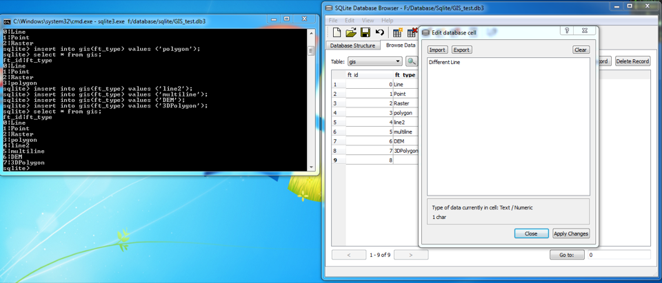

**GUI**

Graphical user interface

**CLI**

Command-line interface

## GUIs can be impressive

[figure not shown]

#### [Pay no attention to that man behind the curtain](http://www.youtube.com/watch?v=YWyCCJ6B2WE)

## CLIs let you get things done

[figure not shown]

## Why the CLI is worth learning

- Typically much more extensive access to features, commands, options
- Command statements can be written down, saved (scripts!)
- Easier automation
- Much "cheaper" to do work on a remote system (no need to transmit all the graphical stuff over the network)

## Let's connect

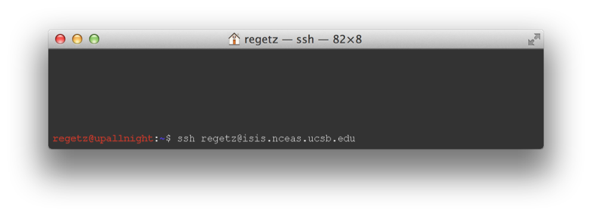

## Lay of the land

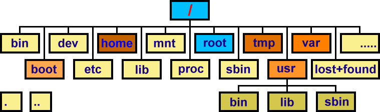

### Navigating and managing files/directories

- `pwd`, `ls`, `cd`
- `~`, `.`, `..`
- `mkdir`, `cp`, `mv`
- `rm`, `rmdir`

## Permissions

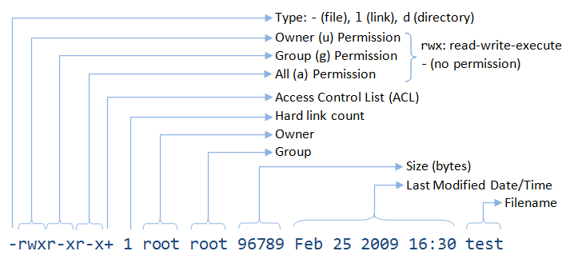

### All files have permissions and ownership

- Change permissions: `chmod`
- Change ownership: `chown`

## Elevate your permissions

[figure not shown]

## Getting help

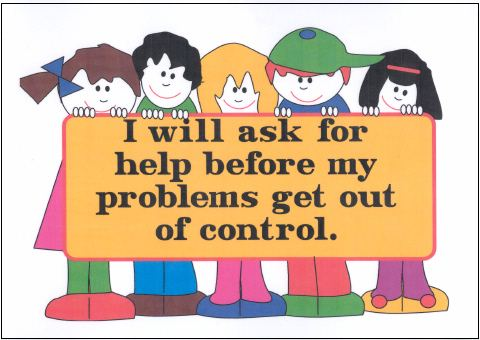

- `<command> -h`, `<command> --help`
- `man`, `info`, `apropos`, `whereis`
- Search the web!

## General command syntax

- `$ command [options] [arguments]`

### where `command` must be an *executable* file on your `PATH`

- `echo $PATH`

### and `options` can usually take two forms

- short form: `-h`
- long form: `--help`

## Text editing

### (Text rules!)

### Some editors

- `vim`
- `emacs`
- `nano`

### `$ nano .bashrc`

## Let's look at our text file

- `cat` print file(s)
- `head` print first few lines of file(s)
- `tail` print last few lines of file(s)
- `less` "pager" – view file interactively

## A sampling of simple commands

- `wc` count lines, words, and/or characters
- `diff` compare two files for differences
- `sort` sort lines in a file
- `uniq` report or filter out repeated lines in a file

## Get into the flow, with pipes

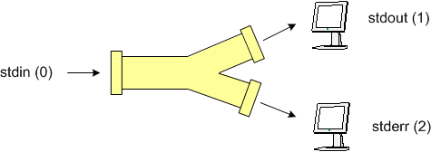

```bash
$ ls *.jpg | wc -l
$ ls *.jpg | wc -l > jpegcount.txt
$ diff <(sort file1.txt) <(sort file2.txt)
$ ls foo 2>/dev/null
$ tee
```

## A sampling of more advanced utilities

- `grep` search files for text
- `sed` filter and transform text
- `find` advanced search for files/directories

## grep

[figure not shown]

## grep

### Show all lines containing "bug" in my R scripts

```bash
$ grep bug *.R
```

### Now count the number of occurrences per file

```bash
$ grep -c bug *.R
```

### Print the names of files that contain bug

```bash
$ grep -l bug *.R
```

### Print the lines of files that **don't** contain bug

```bash
$ grep -v bug *.R
```

## sed

[figure not shown]

## sed

### Remove all lines containing "bug"!

```bash
$ sed '/bug/d' myscript.R
```

### Call them buglets, not bugs!

```bash
$ sed 's/bug/buglet/g' myscript.R
```

```bash
$ sed '/#/ s/bug/buglet/g' myscript.R
```

## find

[figure not shown]

### Like Rover, the Windows search dog. But more useful.

## find

### Show me my pdfs!

```bash
$ find . -iname '*.pdf'
```

### Which files are larger than 10GB?

```bash
$ find . -size +10G -ls
```

## Getting things done

- Process management
  - Like Windows Task Manager, OSX Activity Monitor
  - `top`, `ps`, `jobs`
- Foreground and background
- Stay persistent with `screen`
- Need to go visual?
  - X11 forwarding, x2go, VNC

## Online resources

- http://www.ibm.com/developerworks/linux/library/l-lpic1-v3-103-1/
- http://linuxcommand.org/learning_the_shell.php
- http://www.tuxfiles.org/linuxhelp/cli.html
- http://www.linfo.org/command_line_lesson_1.html
- [Free book!](http://linuxcommand.org/tlcl.php)